# Individual differences

In **Pilot 1**, there are 27 subjects who did the curiosity personal trait questionaire. The following analysis will only include these subjects who had personal trait scores.

# 1 Relationship between trait score and slope of curiosity-memory relationship

## 1.1 Outside

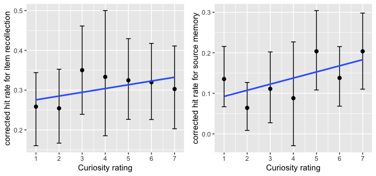

### 1.1.1 Item recollection

#### 1.1.1.1 Correlation with the average score

|  | Model | df | AIC | BIC | logLik | Test | L.Ratio | p-value |
| --- | --- | --- | --- | --- | --- | --- | --- | --- |
| baseline.rating | 1 | 3 | 10.06893 | 19.33172 | -2.0344640 |  |  |  |
| rating.intercept | 2 | 4 | 10.86730 | 23.21769 | -1.4336513 | 1 vs 2 | 1.2016254 | 0.2730 |
| rating.slope | 3 | 6 | 14.86764 | 33.39322 | -1.4338199 | 2 vs 3 | 0.0003374 | 0.9998 |
| tr.intercept | 4 | 7 | 15.24835 | 36.86152 | -0.6241740 | 3 vs 4 | 1.6192920 | 0.2032 |
| tr.slope | 5 | 8 | 17.17905 | 41.87982 | -0.5895249 | 4 vs 5 | 0.0692981 | 0.7924 |

#### 1.1.1.2 Correlation with the PC score

|  | Model | df | AIC | BIC | logLik | Test | L.Ratio | p-value |
| --- | --- | --- | --- | --- | --- | --- | --- | --- |
| baseline.rating | 1 | 3 | 10.06893 | 19.33172 | -2.0344640 |  |  |  |
| rating.intercept | 2 | 4 | 10.86730 | 23.21769 | -1.4336513 | 1 vs 2 | 1.2016254 | 0.2730 |
| rating.slope | 3 | 6 | 14.86764 | 33.39322 | -1.4338199 | 2 vs 3 | 0.0003374 | 0.9998 |
| PC.intercept | 4 | 7 | 15.35864 | 36.97181 | -0.6793197 | 3 vs 4 | 1.5090006 | 0.2193 |
| PC.slope | 5 | 8 | 17.22163 | 41.92240 | -0.6108147 | 4 vs 5 | 0.1370099 | 0.7113 |

#### 1.1.1.3 Correlation with the EC score

|  | Model | df | AIC | BIC | logLik | Test | L.Ratio | p-value |
| --- | --- | --- | --- | --- | --- | --- | --- | --- |
| baseline.rating | 1 | 3 | 10.06893 | 19.33172 | -2.0344640 |  |  |  |
| rating.intercept | 2 | 4 | 10.86730 | 23.21769 | -1.4336513 | 1 vs 2 | 1.2016254 | 0.2730 |
| rating.slope | 3 | 6 | 14.86764 | 33.39322 | -1.4338199 | 2 vs 3 | 0.0003374 | 0.9998 |
| EC.intercept | 4 | 7 | 15.80360 | 37.41678 | -0.9018020 | 3 vs 4 | 1.0640358 | 0.3023 |
| EC.slope | 5 | 8 | 17.25338 | 41.95415 | -0.6266878 | 4 vs 5 | 0.5502284 | 0.4582 |

### 1.1.2 Source memory

#### 1.1.2.1 Correlation with the average score

|  | Model | df | AIC | BIC | logLik | Test | L.Ratio | p-value |
| --- | --- | --- | --- | --- | --- | --- | --- | --- |
| baseline.rating | 1 | 3 | -47.00351 | -37.74072 | 26.50175 |  |  |  |
| rating.intercept | 2 | 4 | -49.72693 | -37.37655 | 28.86347 | 1 vs 2 | 4.723423 | 0.0298 |
| rating.slope | 3 | 6 | -47.42986 | -28.90428 | 29.71493 | 2 vs 3 | 1.702923 | 0.4268 |
| tr.intercept | 4 | 7 | -46.89791 | -25.28473 | 30.44895 | 3 vs 4 | 1.468053 | 0.2257 |
| tr.slope | 5 | 8 | -44.98810 | -20.28733 | 30.49405 | 4 vs 5 | 0.090193 | 0.7639 |

#### 1.1.2.2 Correlation with the PC score

|  | Model | df | AIC | BIC | logLik | Test | L.Ratio | p-value |
| --- | --- | --- | --- | --- | --- | --- | --- | --- |
| baseline.rating | 1 | 3 | -47.00351 | -37.74072 | 26.50175 |  |  |  |
| rating.intercept | 2 | 4 | -49.72693 | -37.37655 | 28.86347 | 1 vs 2 | 4.723423 | 0.0298 |
| rating.slope | 3 | 6 | -47.42986 | -28.90428 | 29.71493 | 2 vs 3 | 1.702923 | 0.4268 |
| PC.intercept | 4 | 7 | -45.99881 | -24.38564 | 29.99941 | 3 vs 4 | 0.568958 | 0.4507 |
| PC.slope | 5 | 8 | -44.93740 | -20.23663 | 30.46870 | 4 vs 5 | 0.938589 | 0.3326 |

#### 1.1.2.3 Correlation with the EC score

|  | Model | df | AIC | BIC | logLik | Test | L.Ratio | p-value |
| --- | --- | --- | --- | --- | --- | --- | --- | --- |
| baseline.rating | 1 | 3 | -47.00351 | -37.74072 | 26.50175 |  |  |  |
| rating.intercept | 2 | 4 | -49.72693 | -37.37655 | 28.86347 | 1 vs 2 | 4.723423 | 0.0298 |
| rating.slope | 3 | 6 | -47.42986 | -28.90428 | 29.71493 | 2 vs 3 | 1.702923 | 0.4268 |
| EC.intercept | 4 | 7 | -47.22515 | -25.61198 | 30.61258 | 3 vs 4 | 1.795296 | 0.1803 |
| EC.slope | 5 | 8 | -45.34275 | -20.64198 | 30.67137 | 4 vs 5 | 0.117597 | 0.7317 |

## 1.2 Inside

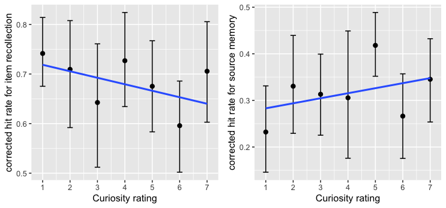

### 1.2.1 Item recollection

#### 1.2.1.1 Correlation with the average score

|  | Model | df | AIC | BIC | logLik | Test | L.Ratio | p-value |
| --- | --- | --- | --- | --- | --- | --- | --- | --- |
| baseline.rating | 1 | 3 | -61.89732 | -52.63453 | 33.94866 |  |  |  |
| rating.intercept | 2 | 4 | -65.60574 | -53.25536 | 36.80287 | 1 vs 2 | 5.708425 | 0.0169 |
| rating.slope | 3 | 6 | -61.60505 | -43.07947 | 36.80253 | 2 vs 3 | 0.000690 | 0.9997 |
| tr.intercept | 4 | 7 | -62.59939 | -40.98621 | 38.29969 | 3 vs 4 | 2.994334 | 0.0836 |
| tr.slope | 5 | 8 | -60.60149 | -35.90072 | 38.30075 | 4 vs 5 | 0.002106 | 0.9634 |

#### 1.2.1.2 Correlation with the PC score

|  | Model | df | AIC | BIC | logLik | Test | L.Ratio | p-value |
| --- | --- | --- | --- | --- | --- | --- | --- | --- |
| baseline.rating | 1 | 3 | -61.89732 | -52.63453 | 33.94866 |  |  |  |
| rating.intercept | 2 | 4 | -65.60574 | -53.25536 | 36.80287 | 1 vs 2 | 5.708425 | 0.0169 |
| rating.slope | 3 | 6 | -61.60505 | -43.07947 | 36.80253 | 2 vs 3 | 0.000690 | 0.9997 |
| PC.intercept | 4 | 7 | -63.44248 | -41.82931 | 38.72124 | 3 vs 4 | 3.837429 | 0.0501 |
| PC.slope | 5 | 8 | -61.46391 | -36.76314 | 38.73196 | 4 vs 5 | 0.021430 | 0.8836 |

```
                  Value  Std.Error  DF   t-value      p-value
(Intercept)  1.20215639 0.23377718 134  5.142317 9.410637e-07
CurRating   -0.01544881 0.00638645 134 -2.418998 1.690571e-02
PC          -0.16456182 0.08176669  25 -2.012578 5.504921e-02
```

#### 1.2.1.3 Correlation with the EC score

|  | Model | df | AIC | BIC | logLik | Test | L.Ratio | p-value |
| --- | --- | --- | --- | --- | --- | --- | --- | --- |
| baseline.rating | 1 | 3 | -61.89732 | -52.63453 | 33.94866 |  |  |  |
| rating.intercept | 2 | 4 | -65.60574 | -53.25536 | 36.80287 | 1 vs 2 | 5.708425 | 0.0169 |
| rating.slope | 3 | 6 | -61.60505 | -43.07947 | 36.80253 | 2 vs 3 | 0.000690 | 0.9997 |
| EC.intercept | 4 | 7 | -60.98154 | -39.36837 | 37.49077 | 3 vs 4 | 1.376488 | 0.2407 |
| EC.slope | 5 | 8 | -58.98315 | -34.28238 | 37.49157 | 4 vs 5 | 0.001606 | 0.9680 |

### 1.2.2 Source memory

#### 1.2.2.1 Correlation with the average score

|  | Model | df | AIC | BIC | logLik | Test | L.Ratio | p-value |
| --- | --- | --- | --- | --- | --- | --- | --- | --- |
| baseline.rating | 1 | 3 | -18.30768 | -9.044895 | 12.15384 |  |  |  |
| rating.intercept | 2 | 4 | -17.60159 | -5.251205 | 12.80080 | 1 vs 2 | 1.293906 | 0.2553 |
| rating.slope | 3 | 6 | -15.69097 | 2.834604 | 13.84549 | 2 vs 3 | 2.089384 | 0.3518 |
| tr.intercept | 4 | 7 | -19.19864 | 2.414539 | 16.59932 | 3 vs 4 | 5.507662 | 0.0189 |
| tr.slope | 5 | 8 | -17.55779 | 7.142981 | 16.77889 | 4 vs 5 | 0.359155 | 0.5490 |

#### 1.2.2.2 Correlation with the PC score

|  | Model | df | AIC | BIC | logLik | Test | L.Ratio | p-value |
| --- | --- | --- | --- | --- | --- | --- | --- | --- |
| baseline.rating | 1 | 3 | -18.30768 | -9.044895 | 12.15384 |  |  |  |
| rating.intercept | 2 | 4 | -17.60159 | -5.251205 | 12.80080 | 1 vs 2 | 1.293906 | 0.2553 |
| rating.slope | 3 | 6 | -15.69097 | 2.834604 | 13.84549 | 2 vs 3 | 2.089384 | 0.3518 |
| PC.intercept | 4 | 7 | -21.51553 | 0.097646 | 17.75776 | 3 vs 4 | 7.824554 | 0.0052 |
| PC.slope | 5 | 8 | -19.95808 | 4.742689 | 17.97904 | 4 vs 5 | 0.442554 | 0.5059 |

```
                   Value   Std.Error  DF    t-value      p-value
(Intercept)  0.720448379 0.145172278 134  4.9627132 2.072996e-06
CurRating    0.009078757 0.009112914 134  0.9962517 3.209235e-01
PC          -0.157771406 0.050046180  25 -3.1525165 4.173492e-03
```

#### 1.2.2.3 Correlation with the EC score

|  | Model | df | AIC | BIC | logLik | Test | L.Ratio | p-value |
| --- | --- | --- | --- | --- | --- | --- | --- | --- |
| baseline.rating | 1 | 3 | -18.30768 | -9.044895 | 12.15384 |  |  |  |
| rating.intercept | 2 | 4 | -17.60159 | -5.251205 | 12.80080 | 1 vs 2 | 1.2939060 | 0.2553 |
| rating.slope | 3 | 6 | -15.69097 | 2.834604 | 13.84549 | 2 vs 3 | 2.0893838 | 0.3518 |
| EC.intercept | 4 | 7 | -15.74347 | 5.869710 | 14.87173 | 3 vs 4 | 2.0524908 | 0.1520 |
| EC.slope | 5 | 8 | -13.89545 | 10.805320 | 14.94773 | 4 vs 5 | 0.1519864 | 0.6966 |

# 2 Relationship between trait score and curiosity ratings

## 2.1 Across all the rooms

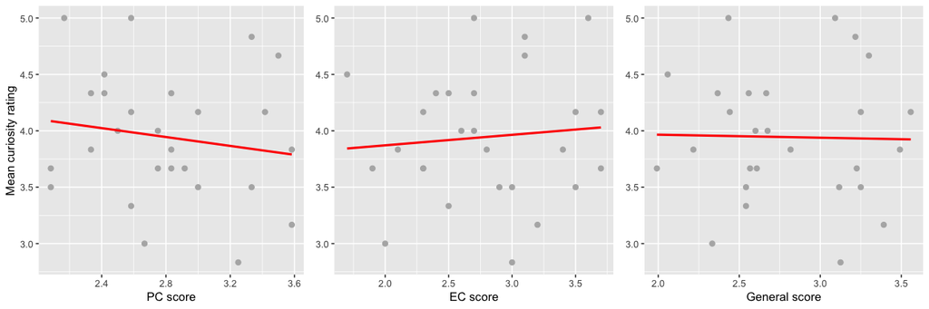

```r
cor.test(trait.ratings$meanCurRating, trait.ratings$PC, method = "pearson")
```

```
    Pearson's product-moment correlation

data:  trait.ratings$meanCurRating and trait.ratings$PC
t = -0.79392, df = 25, p-value = 0.4347
alternative hypothesis: true correlation is not equal to 0
95 percent confidence interval:
 -0.5066409  0.2373384
sample estimates:
       cor
-0.1568194
```

```r
cor.test(trait.ratings$meanCurRating, trait.ratings$EC, method = "pearson")
```

```
    Pearson's product-moment correlation

data:  trait.ratings$meanCurRating and trait.ratings$EC
t = 0.46403, df = 25, p-value = 0.6466
alternative hypothesis: true correlation is not equal to 0
95 percent confidence interval:
 -0.2980717  0.4563964
sample estimates:
       cor
0.09240966
```

```r
cor.test(trait.ratings$meanCurRating, trait.ratings$GN, method = "pearson")
```

```
    Pearson's product-moment correlation

data:  trait.ratings$meanCurRating and trait.ratings$GN
t = -0.10549, df = 25, p-value = 0.9168
alternative hypothesis: true correlation is not equal to 0
95 percent confidence interval:
 -0.3979185  0.3618201
sample estimates:
        cor
-0.02109429
```

## 2.2 Only for the *novel* rooms

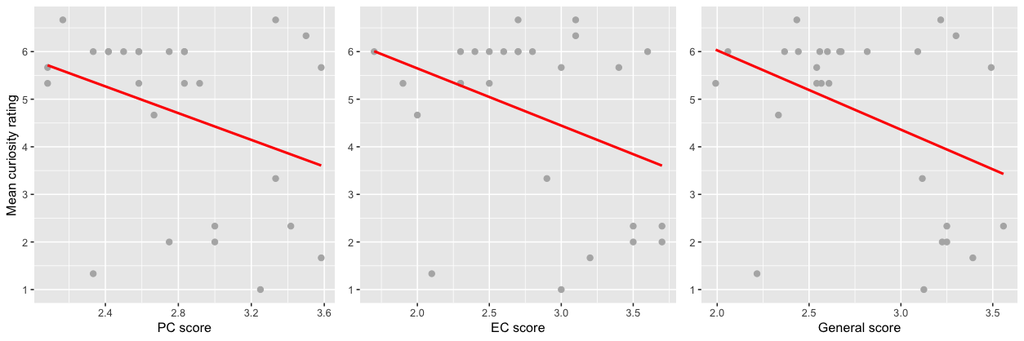

```
    Pearson's product-moment correlation

data:  trait.ratings.novel$meanCurRating and trait.ratings.novel$PC
t = -1.8167, df = 25, p-value = 0.08127
alternative hypothesis: true correlation is not equal to 0
95 percent confidence interval:
 -0.63863186  0.04426315
sample estimates:
      cor
-0.341495


    Pearson's product-moment correlation

data:  trait.ratings.novel$meanCurRating and trait.ratings.novel$EC
t = -1.9532, df = 25, p-value = 0.06207
alternative hypothesis: true correlation is not equal to 0
95 percent confidence interval:
 -0.65351622  0.01873808
sample estimates:
       cor
-0.3638669


    Pearson's product-moment correlation

data:  trait.ratings.novel$meanCurRating and trait.ratings.novel$GN
t = -2.19, df = 25, p-value = 0.03807
alternative hypothesis: true correlation is not equal to 0
95 percent confidence interval:
 -0.67786629 -0.02499858
sample estimates:
       cor
-0.4012012
```

# 3 Relationship between trait score and memory performance

Here *memory performance* refers to the average corrected hit rate for “seen” response for items and average corrected hit rate for source memory.

## 3.1 Outside

### 3.1.1 Item recollection

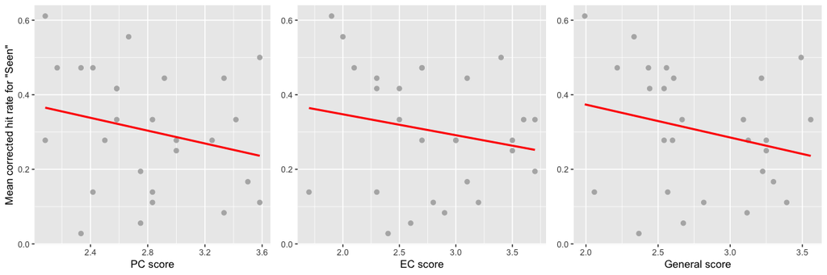

```
    Pearson's product-moment correlation

data:  outside.hit.rate.trait$meanSAcc and outside.hit.rate.trait$PC
t = -1.2265, df = 25, p-value = 0.2314
alternative hypothesis: true correlation is not equal to 0
95 percent confidence interval:
 -0.5669239  0.1558923
sample estimates:
      cor
-0.238235


    Pearson's product-moment correlation

data:  outside.hit.rate.trait$meanSAcc and outside.hit.rate.trait$EC
t = -0.98604, df = 25, p-value = 0.3336
alternative hypothesis: true correlation is not equal to 0
95 percent confidence interval:
 -0.5342165  0.2013363
sample estimates:
      cor
-0.193481


    Pearson's product-moment correlation

data:  outside.hit.rate.trait$meanSAcc and outside.hit.rate.trait$GN
t = -1.2467, df = 25, p-value = 0.224
alternative hypothesis: true correlation is not equal to 0
95 percent confidence interval:
 -0.5695858  0.1520540
sample estimates:
       cor
-0.2419399
```

### 3.1.2 Source memory

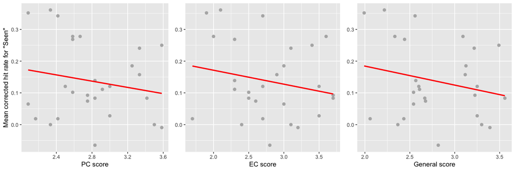

```
    Pearson's product-moment correlation

data:  outside.hit.rate.trait$meanSrcAcc and outside.hit.rate.trait$PC
t = -0.94154, df = 25, p-value = 0.3554
alternative hypothesis: true correlation is not equal to 0
95 percent confidence interval:
 -0.5279419  0.2097066
sample estimates:
       cor
-0.1850546


    Pearson's product-moment correlation

data:  outside.hit.rate.trait$meanSrcAcc and outside.hit.rate.trait$EC
t = -1.0512, df = 25, p-value = 0.3032
alternative hypothesis: true correlation is not equal to 0
95 percent confidence interval:
 -0.5432797  0.1890531
sample estimates:
       cor
-0.2057419


    Pearson's product-moment correlation

data:  outside.hit.rate.trait$meanSrcAcc and outside.hit.rate.trait$GN
t = -1.1427, df = 25, p-value = 0.264
alternative hypothesis: true correlation is not equal to 0
95 percent confidence interval:
 -0.5557545  0.1717630
sample estimates:
       cor
-0.2227932
```

## 3.2 Inside

### 3.2.1 Item recollection

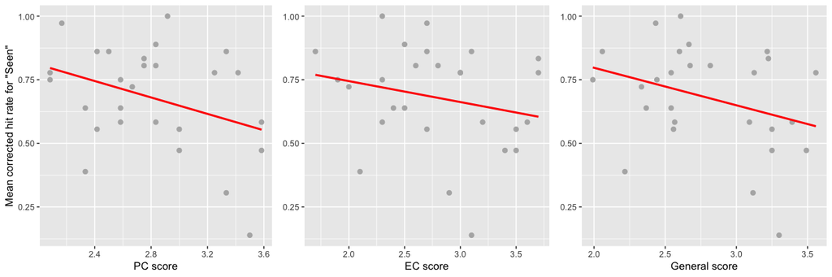

```
    Pearson's product-moment correlation

data:  inside.hit.rate.trait$meanSAcc and inside.hit.rate.trait$PC
t = -1.92, df = 25, p-value = 0.06634
alternative hypothesis: true correlation is not equal to 0
95 percent confidence interval:
 -0.6499464  0.0249408
sample estimates:
       cor
-0.3584707


    Pearson's product-moment correlation

data:  inside.hit.rate.trait$meanSAcc and inside.hit.rate.trait$EC
t = -1.1684, df = 25, p-value = 0.2537
alternative hypothesis: true correlation is not equal to 0
95 percent confidence interval:
 -0.5592017  0.1669048
sample estimates:
       cor
-0.2275412


    Pearson's product-moment correlation

data:  inside.hit.rate.trait$meanSAcc and inside.hit.rate.trait$GN
t = -1.7128, df = 25, p-value = 0.09913
alternative hypothesis: true correlation is not equal to 0
95 percent confidence interval:
 -0.62688187  0.06380244
sample estimates:
       cor
-0.3240688
```

### 3.2.2 Source memory

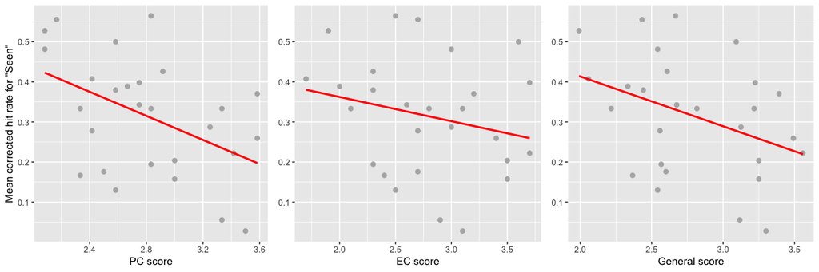

```
    Pearson's product-moment correlation

data:  inside.hit.rate.trait$meanSrcAcc and inside.hit.rate.trait$PC
t = -2.6276, df = 25, p-value = 0.01448
alternative hypothesis: true correlation is not equal to 0
95 percent confidence interval:
 -0.7182402 -0.1034768
sample estimates:
      cor
-0.465198


    Pearson's product-moment correlation

data:  inside.hit.rate.trait$meanSrcAcc and inside.hit.rate.trait$EC
t = -1.1979, df = 25, p-value = 0.2422
alternative hypothesis: true correlation is not equal to 0
95 percent confidence interval:
 -0.5631349  0.1613182
sample estimates:
      cor
-0.232978


    Pearson's product-moment correlation

data:  inside.hit.rate.trait$meanSrcAcc and inside.hit.rate.trait$GN
t = -2.0628, df = 25, p-value = 0.04966
alternative hypothesis: true correlation is not equal to 0
95 percent confidence interval:
 -0.665014719 -0.001599377
sample estimates:
       cor
-0.3813815
```

# 4 Relationship between trait score and memory performance within *Novel* rooms

Here *memory performance* refers to the average corrected hit rate for “seen” response for items and average corrected hit rate for source memory.

## 4.1 Outside

### 4.1.1 Item recollection

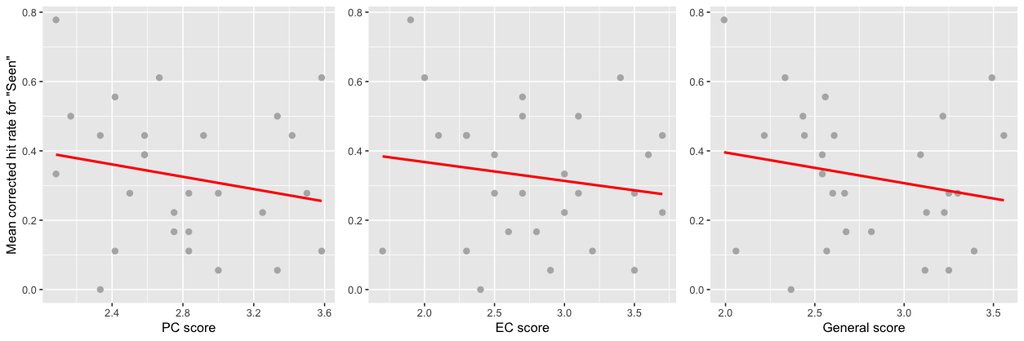

```
    Pearson's product-moment correlation

data:  outside.hit.rate.trait.novel$meanSAcc and outside.hit.rate.trait.novel$PC
t = -1.0467, df = 25, p-value = 0.3052
alternative hypothesis: true correlation is not equal to 0
95 percent confidence interval:
 -0.5426600  0.1899004
sample estimates:
       cor
-0.2049002


    Pearson's product-moment correlation

data:  outside.hit.rate.trait.novel$meanSAcc and outside.hit.rate.trait.novel$EC
t = -0.78824, df = 25, p-value = 0.438
alternative hypothesis: true correlation is not equal to 0
95 percent confidence interval:
 -0.5058057  0.2383978
sample estimates:
       cor
-0.1557239


    Pearson's product-moment correlation

data:  outside.hit.rate.trait.novel$meanSAcc and outside.hit.rate.trait.novel$GN
t = -1.0279, df = 25, p-value = 0.3138
alternative hypothesis: true correlation is not equal to 0
95 percent confidence interval:
 -0.5400567  0.1934476
sample estimates:
       cor
-0.2013696
```

### 4.1.2 Source memory

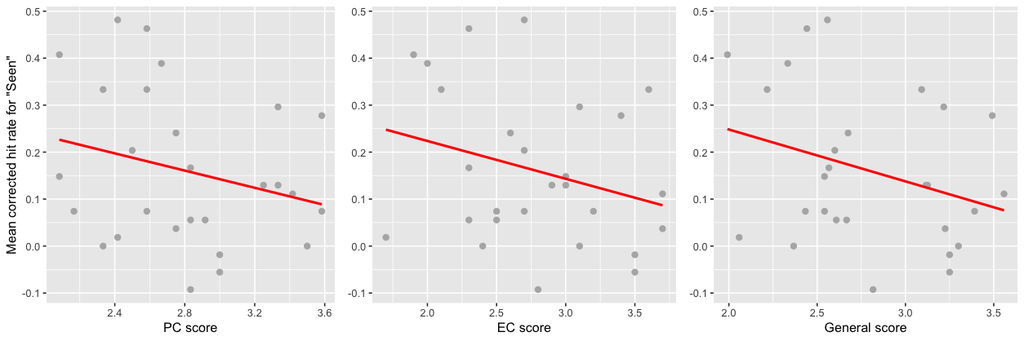

```
    Pearson's product-moment correlation

data:  outside.hit.rate.trait.novel$meanSrcAcc and outside.hit.rate.trait.novel$PC
t = -1.3268, df = 25, p-value = 0.1966
alternative hypothesis: true correlation is not equal to 0
95 percent confidence interval:
 -0.5799691  0.1368714
sample estimates:
      cor
-0.256483


    Pearson's product-moment correlation

data:  outside.hit.rate.trait.novel$meanSrcAcc and outside.hit.rate.trait.novel$EC
t = -1.4612, df = 25, p-value = 0.1564
alternative hypothesis: true correlation is not equal to 0
95 percent confidence interval:
 -0.5968958  0.1113770
sample estimates:
       cor
-0.2805095


    Pearson's product-moment correlation

data:  outside.hit.rate.trait.novel$meanSrcAcc and outside.hit.rate.trait.novel$GN
t = -1.6063, df = 25, p-value = 0.1208
alternative hypothesis: true correlation is not equal to 0
95 percent confidence interval:
 -0.61446028  0.08389838
sample estimates:
       cor
-0.3058674
```

## 4.2 Inside

### 4.2.1 Item recollection

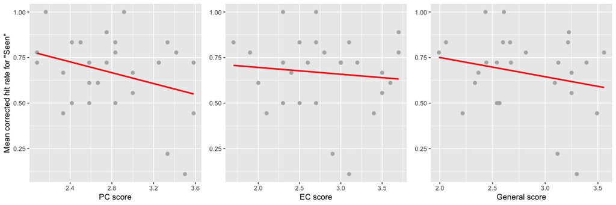

```
    Pearson's product-moment correlation

data:  inside.hit.rate.trait.novel$meanSAcc and inside.hit.rate.trait.novel$PC
t = -1.7077, df = 25, p-value = 0.1001
alternative hypothesis: true correlation is not equal to 0
95 percent confidence interval:
 -0.62630266  0.06475212
sample estimates:
       cor
-0.3232151


    Pearson's product-moment correlation

data:  inside.hit.rate.trait.novel$meanSAcc and inside.hit.rate.trait.novel$EC
t = -0.50681, df = 25, p-value = 0.6167
alternative hypothesis: true correlation is not equal to 0
95 percent confidence interval:
 -0.4631121  0.2902929
sample estimates:
      cor
-0.100846


    Pearson's product-moment correlation

data:  inside.hit.rate.trait.novel$meanSAcc and inside.hit.rate.trait.novel$GN
t = -1.1633, df = 25, p-value = 0.2557
alternative hypothesis: true correlation is not equal to 0
95 percent confidence interval:
 -0.5585303  0.1678537
sample estimates:
       cor
-0.2266153
```

### 4.2.2 Source memory

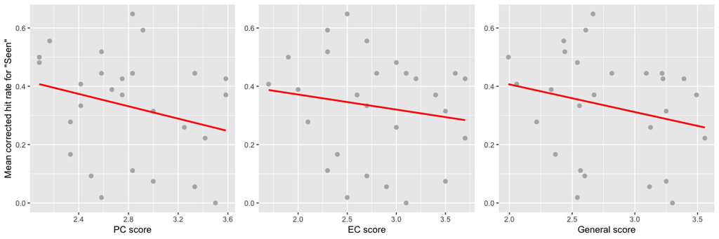

```
    Pearson's product-moment correlation

data:  inside.hit.rate.trait.novel$meanSrcAcc and inside.hit.rate.trait.novel$PC
t = -1.3599, df = 25, p-value = 0.186
alternative hypothesis: true correlation is not equal to 0
95 percent confidence interval:
 -0.5841947  0.1305946
sample estimates:
       cor
-0.2624439


    Pearson's product-moment correlation

data:  inside.hit.rate.trait.novel$meanSrcAcc and inside.hit.rate.trait.novel$EC
t = -0.80682, df = 25, p-value = 0.4274
alternative hypothesis: true correlation is not equal to 0
95 percent confidence interval:
 -0.5085316  0.2349334
sample estimates:
       cor
-0.1593028


    Pearson's product-moment correlation

data:  inside.hit.rate.trait.novel$meanSrcAcc and inside.hit.rate.trait.novel$GN
t = -1.1962, df = 25, p-value = 0.2428
alternative hypothesis: true correlation is not equal to 0
95 percent confidence interval:
 -0.5629180  0.1616275
sample estimates:
       cor
-0.2326777
```

# 5 Relationship between trait score and curiosity ratings between *Familiar* and *Novel* rooms

Here *performance difference* refers to difference in item recollection and source memory between the *novel* and *familiar* rooms (*novel* - *familiar*).

## 5.1 See whether the curiosity ratings are significantly different between *novel* and *familiar* rooms

The average curiosity rating for the *novel* rooms is 4.7 (SD = $\pm$ 1.87).

The average curiosity rating for the *familiar* rooms is 3.19 (SD = $\pm$ 1.55).

```
    One Sample t-test

data:  outside.hit.rate.trait.diff$diffRating
t = 2.4352, df = 26, p-value = 0.02205
alternative hypothesis: true mean is not equal to 0
95 percent confidence interval:
 0.2367577 2.8002794
sample estimates:
mean of x
 1.518519
```

## 5.2 See whether the difference in curiosity ratings are significantly correlated with trait scores

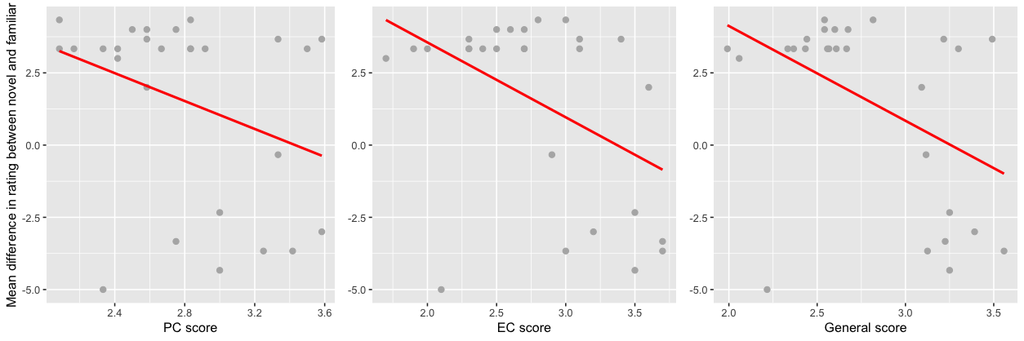

```
    Pearson's product-moment correlation

data:  outside.hit.rate.trait.diff$diffRating and outside.hit.rate.trait.diff$PC
t = -1.8012, df = 25, p-value = 0.08374
alternative hypothesis: true correlation is not equal to 0
95 percent confidence interval:
 -0.63690750  0.04716371
sample estimates:
       cor
-0.3389248


    Pearson's product-moment correlation

data:  outside.hit.rate.trait.diff$diffRating and outside.hit.rate.trait.diff$EC
t = -2.5386, df = 25, p-value = 0.01773
alternative hypothesis: true correlation is not equal to 0
95 percent confidence interval:
 -0.71049613 -0.08780639
sample estimates:
       cor
-0.4527143


    Pearson's product-moment correlation

data:  outside.hit.rate.trait.diff$diffRating and outside.hit.rate.trait.diff$GN
t = -2.5602, df = 25, p-value = 0.01689
alternative hypothesis: true correlation is not equal to 0
95 percent confidence interval:
 -0.71239100 -0.09161246
sample estimates:
       cor
-0.4557596
```

### 5.2.1 Looking at the trait-rating correlation separately for the *novel* and *familiar* rooms

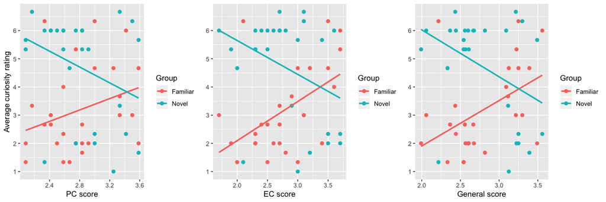

# 6 Relationship between trait score and performance differences between *Familiar* and *Novel* rooms

Here *performance difference* refers to difference in item recollection and source memory between the *novel* and *familiar* rooms (*novel* - *familiar*).

## 6.1 Outside

### 6.1.1 Item recollection

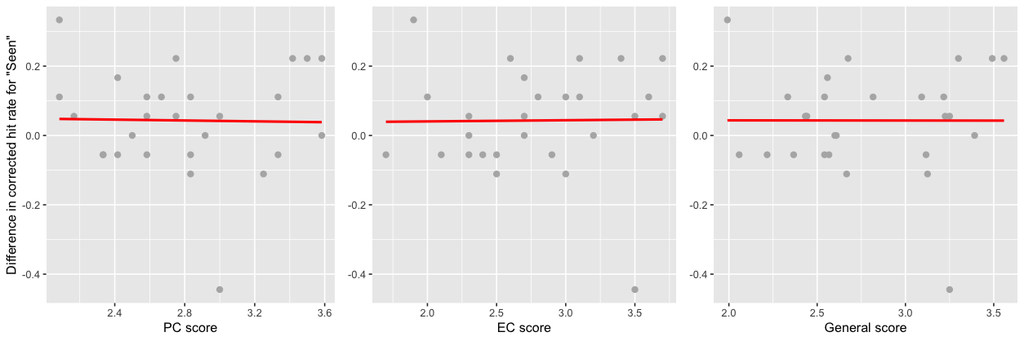

### 6.1.2 Source memory

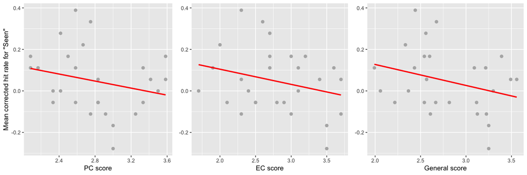

```
    Pearson's product-moment correlation

data:  outside.hit.rate.trait.diff$diffSrcAcc and outside.hit.rate.trait.diff$PC
t = -1.2808, df = 25, p-value = 0.212
alternative hypothesis: true correlation is not equal to 0
95 percent confidence interval:
 -0.5740338  0.1455915
sample estimates:
       cor
-0.2481519


    Pearson's product-moment correlation

data:  outside.hit.rate.trait.diff$diffSrcAcc and outside.hit.rate.trait.diff$EC
t = -1.3807, df = 25, p-value = 0.1796
alternative hypothesis: true correlation is not equal to 0
95 percent confidence interval:
 -0.5868317  0.1266484
sample estimates:
       cor
-0.2661762


    Pearson's product-moment correlation

data:  outside.hit.rate.trait.diff$diffSrcAcc and outside.hit.rate.trait.diff$GN
t = -1.5302, df = 25, p-value = 0.1385
alternative hypothesis: true correlation is not equal to 0
95 percent confidence interval:
 -0.60534266  0.09829621
sample estimates:
       cor
-0.2926494
```

## 6.2 Inside

### 6.2.1 Item recollection

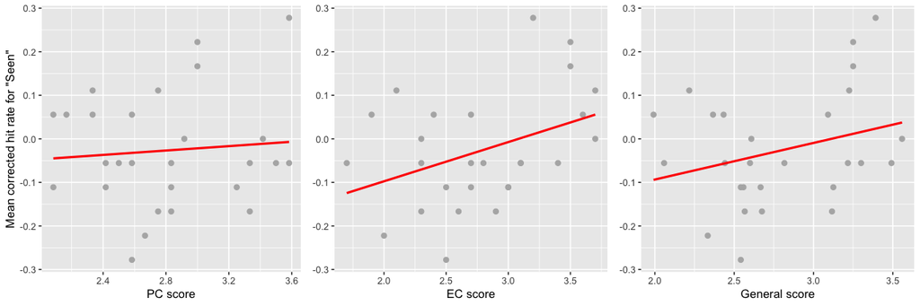

```
    Pearson's product-moment correlation

data:  inside.hit.rate.trait.diff$diffSAcc and inside.hit.rate.trait.diff$PC
t = 0.43455, df = 25, p-value = 0.6676
alternative hypothesis: true correlation is not equal to 0
95 percent confidence interval:
 -0.3034140  0.4517338
sample estimates:
       cor
0.08658318


    Pearson's product-moment correlation

data:  inside.hit.rate.trait.diff$diffSAcc and inside.hit.rate.trait.diff$EC
t = 2.0937, df = 25, p-value = 0.04659
alternative hypothesis: true correlation is not equal to 0
95 percent confidence interval:
 0.007308278 0.668186883
sample estimates:
      cor
0.3862495


    Pearson's product-moment correlation

data:  inside.hit.rate.trait.diff$diffSAcc and inside.hit.rate.trait.diff$GN
t = 1.4955, df = 25, p-value = 0.1473
alternative hypothesis: true correlation is not equal to 0
95 percent confidence interval:
 -0.1048870  0.6011064
sample estimates:
      cor
0.2865483
```

### 6.2.2 Source memory

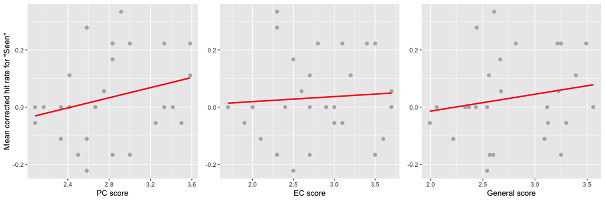

```
    Pearson's product-moment correlation

data:  inside.hit.rate.trait.diff$diffSrcAcc and inside.hit.rate.trait.diff$PC
t = 1.3987, df = 25, p-value = 0.1742
alternative hypothesis: true correlation is not equal to 0
95 percent confidence interval:
 -0.1232319  0.5891025
sample estimates:
      cor
0.2693979


    Pearson's product-moment correlation

data:  inside.hit.rate.trait.diff$diffSrcAcc and inside.hit.rate.trait.diff$EC
t = 0.33338, df = 25, p-value = 0.7416
alternative hypothesis: true correlation is not equal to 0
95 percent confidence interval:
 -0.3216161  0.4355318
sample estimates:
       cor
0.06652893


    Pearson's product-moment correlation

data:  inside.hit.rate.trait.diff$diffSrcAcc and inside.hit.rate.trait.diff$GN
t = 0.90373, df = 25, p-value = 0.3748
alternative hypothesis: true correlation is not equal to 0
95 percent confidence interval:
 -0.2168033  0.5225583
sample estimates:
      cor
0.1778646
```